# SERO: Spatial Emergency Response Optimization

# Hotspot Analysis

Hotspot analysis identifies areas with high concentrations of emergency incidents, helping prioritize resource allocation.

```r
# Define high-risk categories (fatal and serious accidents)
high_risk_categories <- c(1, 2)

# Perform hotspot analysis with different parameters
cat("🔍 Performing hotspot analysis...\n")
```

```
## 🔍 Performing hotspot analysis...
```

```r
# Standard hotspot analysis
hotspots_standard <- sero_hotspots(
  accidents = data$accident,
  risk_categories = high_risk_categories,
  buffer = 800,  # 800 meter buffer
  min_events = 3 # Minimum 3 accidents to form a hotspot
)

# Sensitive hotspot analysis (smaller buffer, fewer events)
hotspots_sensitive <- sero_hotspots(
  accidents = data$accident,
  risk_categories = high_risk_categories,
  buffer = 500,  # 500 meter buffer
  min_events = 2 # Minimum 2 accidents to form a hotspot
)

# Conservative hotspot analysis (larger buffer, more events)
hotspots_conservative <- sero_hotspots(
  accidents = data$accident,
  risk_categories = high_risk_categories,
  buffer = 1000, # 1000 meter buffer
  min_events = 5  # Minimum 5 accidents to form a hotspot
)

# Display results
cat("Standard hotspots found:", nrow(hotspots_standard$hotspots), "\n")
```

```
## Standard hotspots found: 3
```

```r
cat("Sensitive hotspots found:", nrow(hotspots_sensitive$hotspots), "\n")
```

```
## Sensitive hotspots found: 5
```

```r
cat("Conservative hotspots found:", nrow(hotspots_conservative$hotspots), "\n")
```

```
## Conservative hotspots found: 1
```

## Hotspot Comparison Visualization

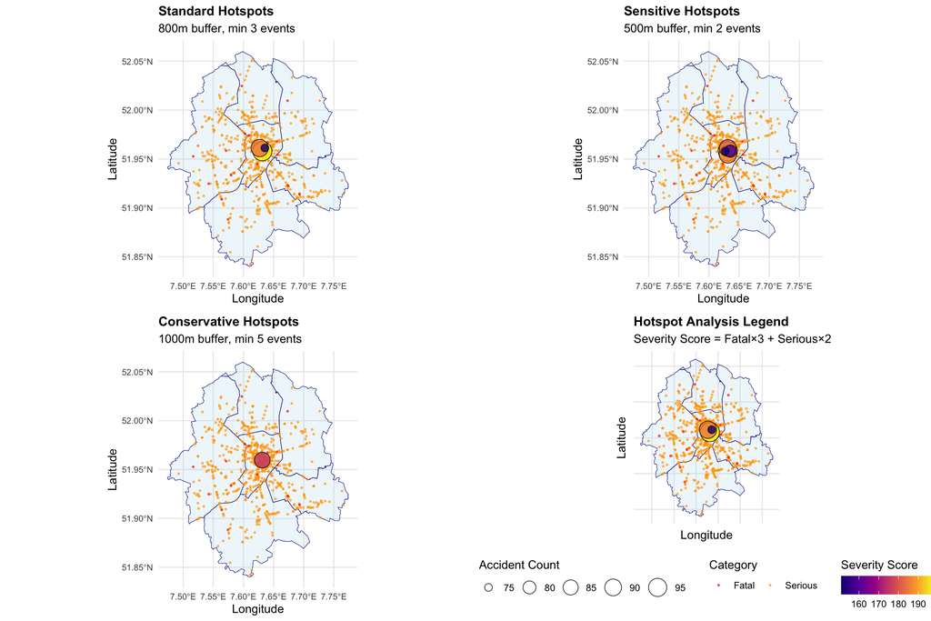

Comparison of hotspot detection methods with different sensitivity levels

```r
# Create hotspot comparison plots with consistent styling and shared legend
p1 <- plot(hotspots_standard, data = data, show_munster = TRUE) +
  labs(title = "Standard Hotspots",
       subtitle = "800m buffer, min 3 events") +
  theme(plot.title = element_text(size = 12, face = "bold"),
        legend.position = "none")

p2 <- plot(hotspots_sensitive, data = data, show_munster = TRUE) +
  labs(title = "Sensitive Hotspots",
       subtitle = "500m buffer, min 2 events") +
  theme(plot.title = element_text(size = 12, face = "bold"),
        legend.position = "none")

p3 <- plot(hotspots_conservative, data = data, show_munster = TRUE) +
  labs(title = "Conservative Hotspots",
       subtitle = "1000m buffer, min 5 events") +
  theme(plot.title = element_text(size = 12, face = "bold"),
        legend.position = "none")

# Create shared legend plot
p4 <- plot(hotspots_standard, data = data, show_munster = TRUE) +
  labs(title = "Hotspot Analysis Legend",
       subtitle = "Severity Score = Fatal×3 + Serious×2") +
  theme(plot.title = element_text(size = 12, face = "bold"),
        legend.position = "bottom",
        legend.box = "horizontal",
        axis.text = element_blank(),
        axis.ticks = element_blank()) +
  guides(
    fill = guide_colorbar(title = "Severity Score", title.position = "top"),
    size = guide_legend(title = "Accident Count", title.position = "top"),
    color = guide_legend(title = "Category", title.position = "top")
  )

# Combine plots with shared legend
grid.arrange(p1, p2, p3, p4, ncol = 2, nrow = 2)
```

# Heatmap Analysis

Heatmap visualization provides continuous risk surfaces using kernel density estimation.

```r
# Create heatmaps with different parameters
cat("🌡️ Generating heatmap analysis...\n")
```

```
## 🌡️ Generating heatmap analysis...
```

```r
# Standard heatmap
heatmap_standard <- sero_heatmap(
  accidents = data$accident,
  risk_categories = high_risk_categories,
  bandwidth = 800,
  grid_size = 50,
  data = data,
  clip_to_munster = TRUE,
  basemap = "districts",
  show_accidents = TRUE,
  color_scheme = "viridis",
  alpha_heatmap = 0.7,
  alpha_basemap = 0.3
)

# High resolution heatmap
heatmap_hires <- sero_heatmap(
  accidents = data$accident,
  risk_categories = high_risk_categories,
  bandwidth = 500,  # Smaller bandwidth for more detail
  grid_size = 75,   # Higher resolution
  data = data,
  clip_to_munster = TRUE,
  basemap = "districts",
  show_accidents = FALSE,
  color_scheme = "plasma",
  alpha_heatmap = 0.8,
  alpha_basemap = 0.2
)

# Smooth heatmap (larger bandwidth)
heatmap_smooth <- sero_heatmap(
  accidents = data$accident,
  risk_categories = high_risk_categories,
  bandwidth = 1200, # Larger bandwidth for smoother surface
  grid_size = 40,   # Lower resolution
  data = data,
  clip_to_munster = TRUE,
  basemap = "districts",
  show_accidents = FALSE,
  color_scheme = "inferno",
  alpha_heatmap = 0.6,
  alpha_basemap = 0.4
)
```

## Heatmap Comparison Visualization

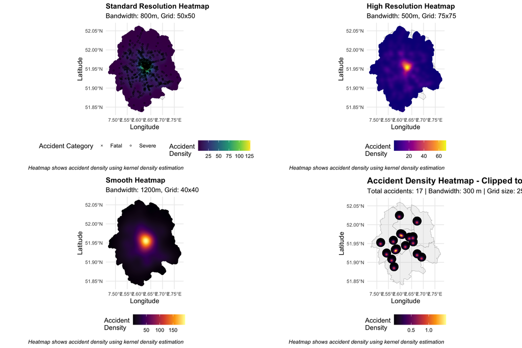

Comparison of kernel density heatmaps with different bandwidth parameters

```r
# Enhance heatmap plots with consistent titles
heatmap_standard_plot <- heatmap_standard +
  labs(title = "Standard Resolution Heatmap",
       subtitle = "Bandwidth: 800m, Grid: 50x50") +
  theme(plot.title = element_text(size = 12, face = "bold"))

heatmap_hires_plot <- heatmap_hires +
  labs(title = "High Resolution Heatmap",
       subtitle = "Bandwidth: 500m, Grid: 75x75") +
  theme(plot.title = element_text(size = 12, face = "bold"))

heatmap_smooth_plot <- heatmap_smooth +
  labs(title = "Smooth Heatmap",
       subtitle = "Bandwidth: 1200m, Grid: 40x40") +
  theme(plot.title = element_text(size = 12, face = "bold"))

# Create category comparison
comparison_plot <- sero_heatmap_compare(
  accidents = data$accident,
  data = data,
  analysis_types = c("urban", "regional", "overview")
)

# Combine plots (showing first 3 from comparison)
if(length(comparison_plot) >= 3) {
  grid.arrange(heatmap_standard_plot, heatmap_hires_plot,
               heatmap_smooth_plot, comparison_plot[[1]],
               ncol = 2, nrow = 2)
} else {
  # Fallback with simple comparison
  simple_comparison <- sero_heatmap(
    accidents = data$accident,
    risk_categories = c(1, 2),
    bandwidth = 800,
    grid_size = 50,
    data = data,
    clip_to_munster = TRUE,
    basemap = "districts",
    show_accidents = FALSE,
    color_scheme = "magma",
    alpha_heatmap = 0.7,
    alpha_basemap = 0.3
  ) +
    labs(title = "Combined Risk Categories",
         subtitle = "Fatal and serious accidents combined") +
    theme(plot.title = element_text(size = 12, face = "bold"))

  grid.arrange(heatmap_standard_plot, heatmap_hires_plot,
               heatmap_smooth_plot, simple_comparison,
               ncol = 2, nrow = 2)
}
```

# Optimal Location Analysis

Finding optimal emergency service locations is crucial for minimizing response times.

```r
# Find optimal locations with different approaches
cat("🎯 Finding optimal emergency service locations...\n")
```

```
## 🎯 Finding optimal emergency service locations...
```

```r
# Standard optimization (3 locations)
optimal_3 <- sero_find_optimal_locations(
  data = data,
  num_locations = 3,
  method = "fast",
  risk_categories = high_risk_categories
)
```

```
## Using 807 high-risk accidents (categories 1, 2 )
## Found 3 optimal emergency service locations
```

```r
# More locations (5 locations)
optimal_5 <- sero_find_optimal_locations(
  data = data,
  num_locations = 5,
  method = "fast",
  risk_categories = high_risk_categories
)
```

```
## Using 807 high-risk accidents (categories 1, 2 )
## Found 5 optimal emergency service locations
```

```r
# Extensive coverage (7 locations)
optimal_7 <- sero_find_optimal_locations(
  data = data,
  num_locations = 7,
  method = "fast",
  risk_categories = high_risk_categories
)
```

```
## Using 807 high-risk accidents (categories 1, 2 )
## Found 7 optimal emergency service locations
```

```r
# Display results
cat("✅ Optimal locations found:\n")
```

```
## ✅ Optimal locations found:
```

```r
cat("  3 locations: Average coverage =", round(mean(optimal_3$accessibility_score), 2), "\n")
```

```
##   3 locations: Average coverage = 3.1
```

```r
cat("  5 locations: Average coverage =", round(mean(optimal_5$accessibility_score), 2), "\n")
```

```
##   5 locations: Average coverage = 2.21
```

```r
cat("  7 locations: Average coverage =", round(mean(optimal_7$accessibility_score), 2), "\n")
```

```
##   7 locations: Average coverage = 1.99
```

## Optimal Location Comparison

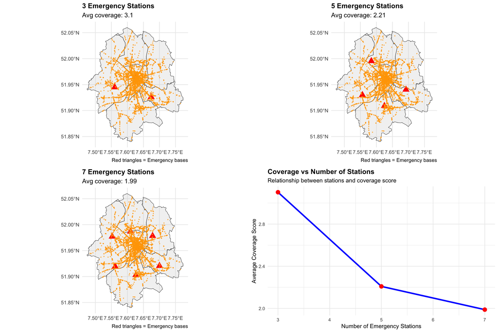

Comparison of optimal emergency service locations with different coverage strategies

```r
# Create optimal location plots
p1 <- sero_plot_optimal_quick(optimal_3, data$districts, accidents = data$accident) +
  labs(title = "3 Emergency Stations",
       subtitle = paste("Avg coverage:", round(mean(optimal_3$accessibility_score), 2))) +
  theme(plot.title = element_text(size = 12, face = "bold"))

p2 <- sero_plot_optimal_quick(optimal_5, data$districts, accidents = data$accident) +
  labs(title = "5 Emergency Stations",
       subtitle = paste("Avg coverage:", round(mean(optimal_5$accessibility_score), 2))) +
  theme(plot.title = element_text(size = 12, face = "bold"))

p3 <- sero_plot_optimal_quick(optimal_7, data$districts, accidents = data$accident) +
  labs(title = "7 Emergency Stations",
       subtitle = paste("Avg coverage:", round(mean(optimal_7$accessibility_score), 2))) +
  theme(plot.title = element_text(size = 12, face = "bold"))

# Create coverage analysis plot
coverage_data <- data.frame(
  locations = c(3, 5, 7),
  avg_coverage = c(mean(optimal_3$accessibility_score),
                   mean(optimal_5$accessibility_score),
                   mean(optimal_7$accessibility_score))
)

p4 <- ggplot(coverage_data, aes(x = locations, y = avg_coverage)) +
  geom_line(color = "blue", size = 1.2) +
  geom_point(color = "red", size = 3) +
  labs(title = "Coverage vs Number of Stations",
       subtitle = "Relationship between stations and coverage score",
       x = "Number of Emergency Stations",
       y = "Average Coverage Score") +
  theme(plot.title = element_text(size = 12, face = "bold"))

# Combine plots
grid.arrange(p1, p2, p3, p4, ncol = 2, nrow = 2)
```

# Route Optimization and Basemap Integration

Route optimization calculates the fastest paths from emergency stations to incident locations.

```r
# Create routes with different scenarios
cat("🚗 Calculating emergency response routes...\n")
```

```
## 🚗 Calculating emergency response routes...
```

```r
# Use optimal 5-location setup for routing
sample_accidents <- data$accident[data$accident$UKATEGORIE %in% high_risk_categories, ]
sample_accidents <- sample_accidents[sample(nrow(sample_accidents), 15), ]

# Create routes
routes <- sero_routes(
  locations = optimal_5,
  accidents = sample_accidents,
  max_routes = 15,
  data = data
)

# Display route summary
cat("✅ Route Analysis Results:\n")
```

```
## ✅ Route Analysis Results:
```

```r
cat("  Total routes calculated:", nrow(routes$routes), "\n")
```

```
##   Total routes calculated: 15
```

```r
cat("  Average travel time:", round(mean(routes$routes$estimated_time), 2), "minutes\n")
```

```
##   Average travel time: 6.14 minutes
```

```r
cat("  Average distance:", round(mean(routes$routes$distance)/1000, 2), "km\n")
```

```
##   Average distance: 3.07 km
```

```r
cat("  Routes under 5 minutes:", sum(routes$routes$estimated_time < 5), "\n")
```

```
##   Routes under 5 minutes: 8
```

```r
cat("  Routes 5-10 minutes:", sum(routes$routes$estimated_time >= 5 & routes$routes$estimated_time < 10), "\n")
```

```
##   Routes 5-10 minutes: 6
```

```r
cat("  Routes over 10 minutes:", sum(routes$routes$estimated_time >= 10), "\n")
```

```
##   Routes over 10 minutes: 1
```

## Route Visualization with Different Basemaps

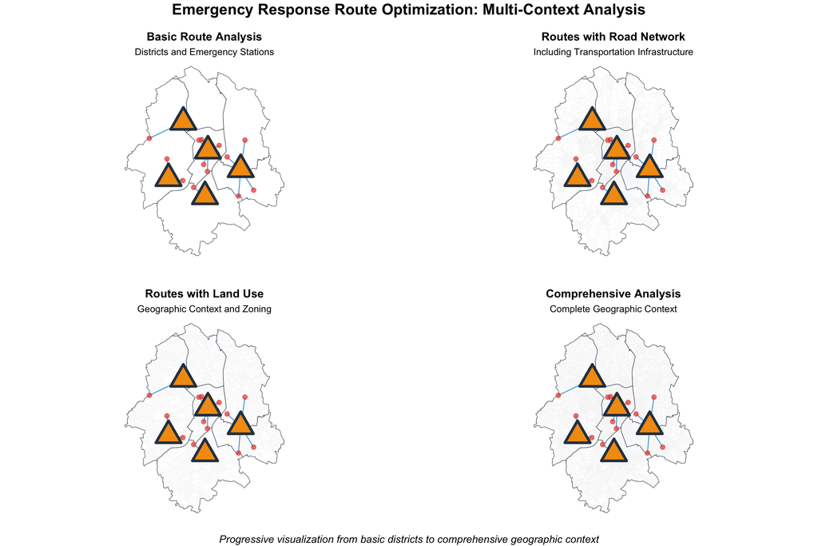

Emergency response routes displayed with different spatial contexts

```r
# Create enhanced route visualization function
enhanced_route_plot <- function(routes, optimal_locations, sample_accidents, data,
                               show_roads = TRUE, show_landuse = TRUE, show_districts = TRUE) {

  # Check if routes object has the expected structure
  if (is.null(routes$routes) || nrow(routes$routes) == 0) {
    # Create a basic plot with locations and accidents
    p <- ggplot()

    # Add district boundaries
    if (show_districts && "districts" %in% names(data)) {
      districts_viz <- sf::st_transform(data$districts, 4326)
      p <- p + geom_sf(data = districts_viz,
                       fill = "transparent",
                       color = "#2c3e50",
                       size = 1.2,
                       alpha = 0.8)
    }

    # Add accident locations
    accidents_viz <- sf::st_transform(sample_accidents, 4326)
    p <- p + geom_sf(data = accidents_viz,
                     color = "#e74c3c",
                     size = 2,
                     alpha = 0.7)

    # Add emergency stations (top layer)
    locations_viz <- sf::st_transform(optimal_locations, 4326)
    p <- p + geom_sf(data = locations_viz,
                     size = 6,
                     color = "#2c3e50",
                     fill = "#f39c12",
                     shape = 24,
                     stroke = 2)

    p <- p +
      theme_void() +
      theme(
        plot.title = element_text(size = 12, face = "bold", hjust = 0.5),
        plot.subtitle = element_text(size = 10, hjust = 0.5),
        legend.position = "none",
        panel.background = element_rect(fill = "white", color = NA),
        plot.background = element_rect(fill = "white", color = NA),
        plot.margin = margin(10, 10, 10, 10)
      )

    return(p)
  }

  # Transform data to consistent CRS for visualization
  routes_viz <- sf::st_transform(routes$routes, 4326)
  accidents_viz <- sf::st_transform(sample_accidents, 4326)
  locations_viz <- sf::st_transform(optimal_locations, 4326)

  # Base plot
  p <- ggplot()

  # Add landuse layer (background)
  if (show_landuse && "landuse" %in% names(data)) {
    landuse_viz <- sf::st_transform(data$landuse, 4326)
    p <- p + geom_sf(data = landuse_viz,
                     fill = "#f5f5f5",
                     color = "#e0e0e0",
                     size = 0.1,
                     alpha = 0.3)
  }

  # Add road network
  if (show_roads && "roads" %in% names(data)) {
    roads_viz <- sf::st_transform(data$roads, 4326)
    p <- p + geom_sf(data = roads_viz,
                     color = "#d3d3d3",
                     size = 0.2,
                     alpha = 0.4)
  }

  # Add district boundaries
  if (show_districts && "districts" %in% names(data)) {
    districts_viz <- sf::st_transform(data$districts, 4326)
    p <- p + geom_sf(data = districts_viz,
                     fill = "transparent",
                     color = "#2c3e50",
                     size = 1.2,
                     alpha = 0.8)
  }

  # Add route lines
  p <- p + geom_sf(data = routes_viz,
                   color = "#3498db",
                   size = 1.5,
                   alpha = 0.8)

  # Add accident locations
  p <- p + geom_sf(data = accidents_viz,
                   color = "#e74c3c",
                   size = 2,
                   alpha = 0.7)

  # Add emergency stations (TOP LAYER - always visible)
  p <- p + geom_sf(data = locations_viz,
                   size = 8,
                   color = "#2c3e50",
                   fill = "#f39c12",
                   shape = 24,
                   stroke = 2)

  # Professional styling optimized for grid layout
  p <- p +
    theme_void() +
    theme(
      plot.title = element_text(size = 12, face = "bold", hjust = 0.5),
      plot.subtitle = element_text(size = 10, hjust = 0.5),
      legend.position = "none",
      panel.background = element_rect(fill = "white", color = NA),
      plot.background = element_rect(fill = "white", color = NA),
      plot.margin = margin(10, 10, 10, 10)
    )

  return(p)
}

# Create four versions of the route visualization for comprehensive grid display
route_basic <- enhanced_route_plot(routes, optimal_5, sample_accidents, data,
                                  show_roads = FALSE, show_landuse = FALSE, show_districts = TRUE) +
  labs(title = "Basic Route Analysis",
       subtitle = "Districts and Emergency Stations")

route_with_roads <- enhanced_route_plot(routes, optimal_5, sample_accidents, data,
                                       show_roads = TRUE, show_landuse = FALSE, show_districts = TRUE) +
  labs(title = "Routes with Road Network",
       subtitle = "Including Transportation Infrastructure")

route_with_landuse <- enhanced_route_plot(routes, optimal_5, sample_accidents, data,
                                         show_roads = FALSE, show_landuse = TRUE, show_districts = TRUE) +
  labs(title = "Routes with Land Use",
       subtitle = "Geographic Context and Zoning")

route_comprehensive <- enhanced_route_plot(routes, optimal_5, sample_accidents, data,
                                         show_roads = TRUE, show_landuse = TRUE, show_districts = TRUE) +
  labs(title = "Comprehensive Analysis",
       subtitle = "Complete Geographic Context")

# Create a 2x2 grid layout for route visualizations
route_grid <- grid.arrange(
  route_basic,
  route_with_roads,
  route_with_landuse,
  route_comprehensive,
  ncol = 2,
  nrow = 2,
  top = textGrob("Emergency Response Route Optimization: Multi-Context Analysis",
                 gp = gpar(fontsize = 16, fontface = "bold")),
  bottom = textGrob("Progressive visualization from basic districts to comprehensive geographic context",
                    gp = gpar(fontsize = 11, fontface = "italic"))
)
```

```r
route_grid
```

## Route Performance Analysis

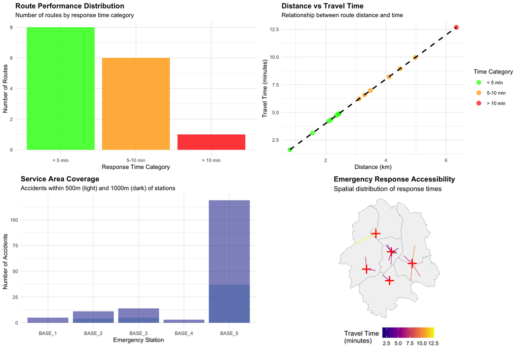

Analysis of emergency response route performance and accessibility

```r
# Create performance analysis
routes_sf <- routes$routes
routes_sf$time_category <- cut(routes_sf$estimated_time,
                              breaks = c(0, 5, 10, Inf),
                              labels = c("< 5 min", "5-10 min", "> 10 min"))

# Performance summary plot
performance_summary <- routes_sf %>%
  st_drop_geometry() %>%
  group_by(time_category) %>%
  summarise(count = n(), .groups = 'drop')

p1 <- ggplot(performance_summary, aes(x = time_category, y = count, fill = time_category)) +
  geom_bar(stat = "identity", alpha = 0.8) +
  scale_fill_manual(values = c("green", "orange", "red"), guide = "none") +
  labs(title = "Route Performance Distribution",
       subtitle = "Number of routes by response time category",
       x = "Response Time Category",
       y = "Number of Routes") +
  theme(plot.title = element_text(size = 12, face = "bold"))

# Distance vs Time analysis
p2 <- ggplot(st_drop_geometry(routes_sf), aes(x = distance/1000, y = estimated_time)) +
  geom_point(aes(color = time_category), size = 3, alpha = 0.7) +
  geom_smooth(method = "lm", se = FALSE, color = "black", linetype = "dashed") +
  scale_color_manual(values = c("green", "orange", "red"), name = "Time Category") +
  labs(title = "Distance vs Travel Time",
       subtitle = "Relationship between route distance and time",
       x = "Distance (km)",
       y = "Travel Time (minutes)") +
  theme(plot.title = element_text(size = 12, face = "bold"))

# Service area coverage
service_coverage <- routes$service_locations %>%
  st_drop_geometry() %>%
  group_by(location_id) %>%
  summarise(
    accidents_500m = first(accident_count_500m),
    accidents_1000m = first(accident_count_1000m),
    .groups = 'drop'
  )

p3 <- ggplot(service_coverage, aes(x = location_id)) +
  geom_bar(aes(y = accidents_500m), stat = "identity", fill = "lightblue", alpha = 0.7) +
  geom_bar(aes(y = accidents_1000m), stat = "identity", fill = "darkblue", alpha = 0.5) +
  labs(title = "Service Area Coverage",
       subtitle = "Accidents within 500m (light) and 1000m (dark) of stations",
       x = "Emergency Station",
       y = "Number of Accidents") +
  theme(plot.title = element_text(size = 12, face = "bold"))

# Accessibility heatmap
routes_wgs84 <- st_transform(routes_sf, 4326)
locations_wgs84 <- st_transform(routes$service_locations, 4326)
districts_wgs84 <- st_transform(data$districts, 4326)

p4 <- ggplot() +
  geom_sf(data = districts_wgs84, fill = "lightgray", color = "darkgray", alpha = 0.3) +
  geom_sf(data = routes_wgs84, aes(color = estimated_time), size = 1.2, alpha = 0.8) +
  geom_sf(data = locations_wgs84, color = "red", size = 4, shape = 3, stroke = 1.5) +
  scale_color_viridis_c(name = "Travel Time\n(minutes)", option = "plasma") +
  theme_void() +
  labs(title = "Emergency Response Accessibility",
       subtitle = "Spatial distribution of response times") +
  theme(plot.title = element_text(size = 12, face = "bold"),
        legend.position = "bottom")

# Combine plots
grid.arrange(p1, p2, p3, p4, ncol = 2, nrow = 2)
```

# Complete Workflow Integration

The SERO package provides an integrated workflow for comprehensive emergency response analysis.

```r
# Run complete emergency response workflow
cat("🔄 Running complete emergency response workflow...\n")
```

```
## 🔄 Running complete emergency response workflow...
```

```r
workflow_results <- sero_emergency_workflow(
  interactive = FALSE,
  quick = TRUE,
  num_locations = 4,
  risk_categories = c(1, 2)
)
```

```
## SERO: Emergency Response Optimization Workflow
## ==================================================
## Step 1: Loading spatial data...
## Loading munster_districtsshp ...
## Loading population_density ...
## Loading munster_roadsshp ...
## Loading accidents ...
## Loading munster_landuseshp ...
## Data loaded successfully!
## Loaded Munster dataset with 5 layers
##
## Step 2: Creating accident visualization...
```

```
## Accident map created
##
## Step 3: Finding optimal emergency locations...
## Using 807 high-risk accidents (categories 1, 2 )
## Found 4 optimal emergency service locations
##
## Step 4: Calculating routes to accident scenes...
## Routes calculated
##
## Step 5: Creating visualizations...
## Optimal location map created
## Route map created
##
## Step 6: Performance Summary
## ============================
## Emergency bases found: 4
## Average accessibility score: 1.955
## Best accessibility score: 6.173
## Average accidents covered (500m): 6.5
## Maximum accidents covered (500m): 24
## Routes calculated: 5
## Average response time: 6.2 minutes
## Maximum response time: 9.8 minutes
```

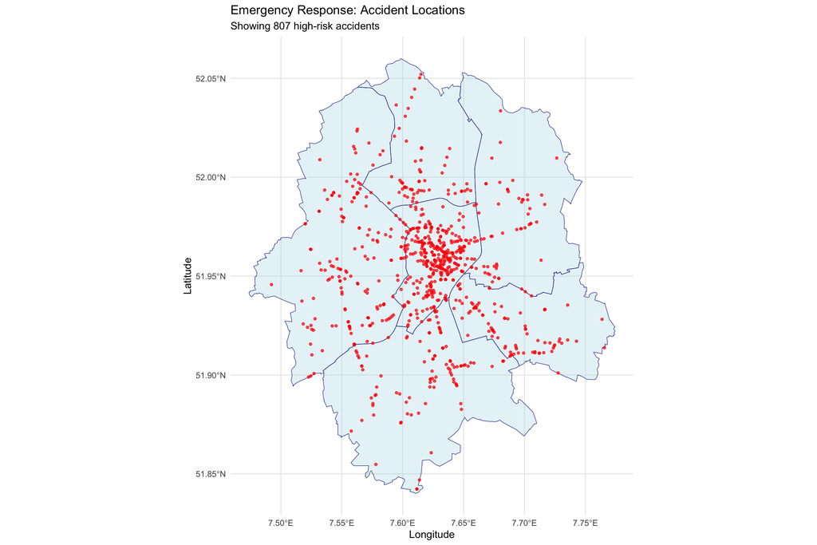

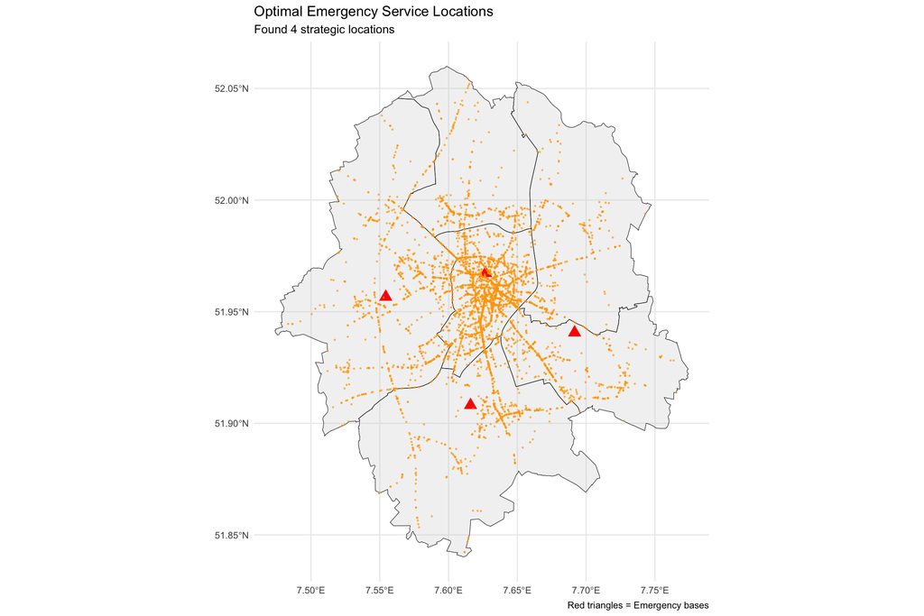

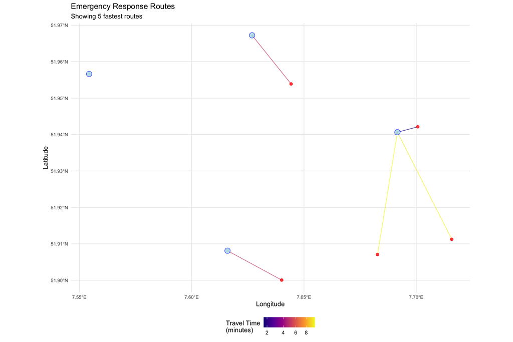

```
##
## Workflow completed successfully!
```

```r
# Display workflow summary
cat("📋 Complete Workflow Results:\n")
```

```
## 📋 Complete Workflow Results:
```

```r
cat("==============================\n")
summary_data <- workflow_results$summary
for (metric in names(summary_data)) {
  cat(sprintf("%-25s: %s\n", metric, summary_data[[metric]]))
}
```

```
## num_locations            : 4
## avg_accessibility        : 1.95475
## total_accidents          : 5695
## num_routes               : 5
## avg_response_time        : 6.18163779371064
```

# Performance Metrics Summary

```r
# Create comprehensive performance summary
cat("📊 SERO Package Performance Summary\n")
```

```
## 📊 SERO Package Performance Summary
```

```r
cat("===================================\n")
# Data statistics
total_accidents <- nrow(data$accident)
high_risk_accidents <- nrow(data$accident[data$accident$UKATEGORIE %in% c(1,2), ])
districts_count <- nrow(data$districts)

# Hotspot statistics
hotspot_counts <- c(
  standard = nrow(hotspots_standard$hotspots),
  sensitive = nrow(hotspots_sensitive$hotspots),
  conservative = nrow(hotspots_conservative$hotspots)
)

# Location optimization statistics
location_coverage <- c(
  three_locations = mean(optimal_3$accessibility_score),
  five_locations = mean(optimal_5$accessibility_score),
  seven_locations = mean(optimal_7$accessibility_score)
)

# Route performance statistics
route_performance <- c(
  total_routes = nrow(routes$routes),
  avg_time = mean(routes$routes$estimated_time),
  avg_distance = mean(routes$routes$distance)/1000,
  fast_routes = sum(routes$routes$estimated_time < 5),
  medium_routes = sum(routes$routes$estimated_time >= 5 & routes$routes$estimated_time < 10),
  slow_routes = sum(routes$routes$estimated_time >= 10)
)

# Create summary table
summary_table <- data.frame(
  Metric = c("Total Accidents", "High-Risk Accidents", "Districts",
             "Standard Hotspots", "Sensitive Hotspots", "Conservative Hotspots",
             "3-Location Coverage", "5-Location Coverage", "7-Location Coverage",
             "Total Routes", "Avg Travel Time (min)", "Avg Distance (km)",
             "Fast Routes (<5min)", "Medium Routes (5-10min)", "Slow Routes (>10min)"),
  Value = c(total_accidents, high_risk_accidents, districts_count,
            hotspot_counts,
            round(location_coverage, 2),
            route_performance[1], round(route_performance[2:3], 2),
            route_performance[4:6])
)

kable(summary_table, caption = "SERO Package Analysis Summary", align = "lr")
```

SERO Package Analysis Summary

| Metric | Value |
| --- | --- |
| Total Accidents | 5695.00 |
| High-Risk Accidents | 807.00 |
| Districts | 6.00 |
| Standard Hotspots | 3.00 |
| Sensitive Hotspots | 5.00 |
| Conservative Hotspots | 1.00 |
| 3-Location Coverage | 3.10 |
| 5-Location Coverage | 2.21 |
| 7-Location Coverage | 1.99 |
| Total Routes | 15.00 |
| Avg Travel Time (min) | 6.14 |
| Avg Distance (km) | 3.07 |
| Fast Routes (<5min) | 8.00 |
| Medium Routes (5-10min) | 6.00 |
| Slow Routes (>10min) | 1.00 |

# Key Findings and Recommendations

## Recommendations

1. **Optimal Configuration**: Use 5 emergency stations for balanced coverage and efficiency
2. **Hotspot Focus**: Prioritize standard hotspot detection for resource allocation
3. **Route Monitoring**: Monitor routes over 10 minutes for improvement opportunities
4. **Basemap Integration**: Use comprehensive basemap view for strategic planning

# Conclusion

The SERO package provides a comprehensive toolkit for emergency response optimization, offering:

- **Flexible Analysis**: Multiple approaches for hotspot detection and location optimization
- **Visual Integration**: Rich basemap support for spatial context
- **Performance Metrics**: Detailed analysis of response times and coverage
- **Workflow Integration**: Complete end-to-end analysis capabilities

This demonstration shows how SERO can be used to make data-driven decisions for emergency service planning and optimization.

*Generated with SERO v0.1.0 on 2025-07-18*